# 3. Performance Benchmark with other packages

This vignette presents some performance tests ran between `fundiversity` and other functional diversity packages. Note that to avoid the dependency on other packages, this vignette is [**pre-computed**](https://ropensci.org/technotes/2019/12/08/precompute-vignettes/).

# Other packages to compute FD indices

## Main functions

Here is a table that summarizes the comparable functions (and their arguments) for functions included in `fundiversity`. Note that the package name is indicated before `::` followed by the function name.

[output not shown]

The other packages are thus: `adiv` (Pavoine 2020), `BAT` (Cardoso, Rigal, and Carvalho 2015), `betapart` (Baselga and Orme 2012), `FD` (Laliberté, Legendre, and Shipley 2014), `hillR` (Li 2018), and `mFD` (Magneville et al. 2022). For fairness of comparison, even if `FD::dbFD()` contains most indices we’re not considering it as it computes all indices together for each call, and would necessarily be slower.

## Benchmark between packages

We will now benchmark the functions included in `fundiversity` with the corresponding function in other packages using the `microbenchmark::microbenchmark()` function. We will use the fairly small (~220 species, 8 sites, 4 traits) provided dataset in `fundiversity`.

```r
tictoc::tic()  # Time execution of vignette
library(fundiversity)
data("traits_birds", package = "fundiversity")
data("site_sp_birds", package = "fundiversity")

dist_traits_birds <- dist(traits_birds)
```

### Functional Dispersion (FDis)

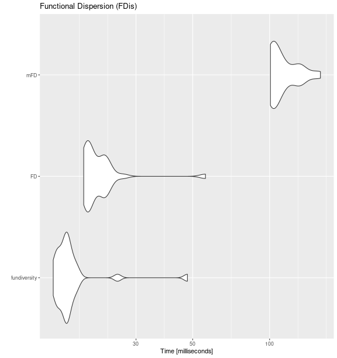

```r
fdis_bench <- microbenchmark::microbenchmark(
  fundiversity = {
    fundiversity::fd_fdis(traits_birds, site_sp_birds)
  },
  FD = {
    FD::fdisp(dist_traits_birds, site_sp_birds)
  },
  mFD = {
    mFD::alpha.fd.multidim(
    traits_birds, site_sp_birds, ind_vect = "fdis",
    scaling = FALSE, verbose = FALSE, details_returned = FALSE
  )
  },
  times = 30
)

ggplot2::autoplot(fdis_bench) +
  labs(title = "Functional Dispersion (FDis)")
```

### Functional Divergence (FDiv)

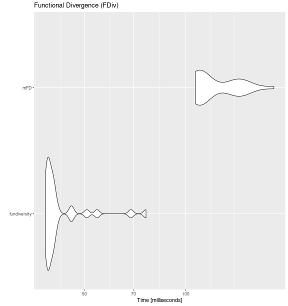

```r
fdiv_bench <- microbenchmark::microbenchmark(
  fundiversity = fd_fdiv(traits_birds, site_sp_birds),
  mFD = mFD::alpha.fd.multidim(
    traits_birds, site_sp_birds, ind_vect = "fdiv",
    scaling = FALSE, verbose = FALSE
  ),
  times = 30
)

ggplot2::autoplot(fdiv_bench) +
  labs(title = "Functional Divergence (FDiv)")
```

### Functional Evenness (FEve)

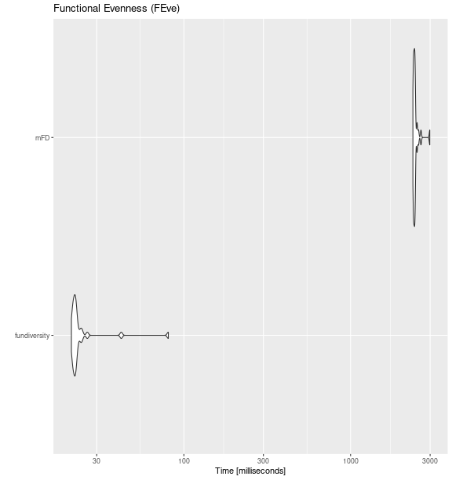

```r
feve_bench <- microbenchmark::microbenchmark(
  fundiversity = fd_feve(traits_birds, site_sp_birds),
  mFD = mFD::alpha.fd.multidim(
    traits_birds, site_sp_birds, ind_vect = "feve",
    scaling = FALSE, verbose = FALSE
  ),
  times = 30
)

ggplot2::autoplot(feve_bench) +
  labs(title = "Functional Evenness (FEve)")
```

### Functional Richness (FRic)

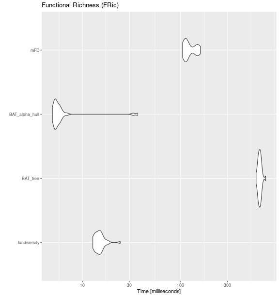

```r
fric_bench <- microbenchmark::microbenchmark(
  fundiversity = fd_fric(traits_birds, site_sp_birds),
  BAT_tree = BAT::alpha(
    site_sp_birds, traits_birds
  ),
  BAT_alpha_hull = BAT::hull.alpha(
    BAT::hull.build(site_sp_birds, traits_birds)
  ),
  mFD = mFD::alpha.fd.multidim(
    traits_birds, site_sp_birds, ind_vect = "fric",
    scaling = FALSE, verbose = FALSE
  ),
  times = 30
)

ggplot2::autoplot(fric_bench) +
  labs(title = "Functional Richness (FRic)")
```

### Functional Richness Intersection (FRic_intersect)

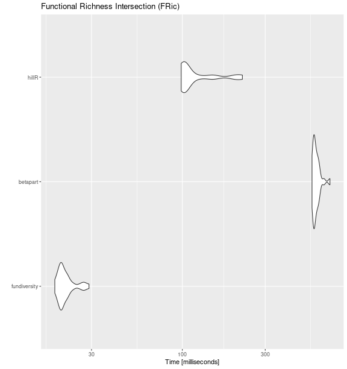

```r
fric_bench <- microbenchmark::microbenchmark(
  fundiversity  = fd_fric_intersect(traits_birds, site_sp_birds) ,
  betapart = betapart::functional.beta.pair(
    site_sp_birds, traits_birds
  ),
  hillR = hillR::hill_func_parti_pairwise(
    site_sp_birds, traits_birds, .progress = FALSE
  ),
  times = 30
)

ggplot2::autoplot(fric_bench) +
  labs(title = "Functional Richness Intersection (FRic)")
```

### Rao’s Quadratic Entropy (Q)

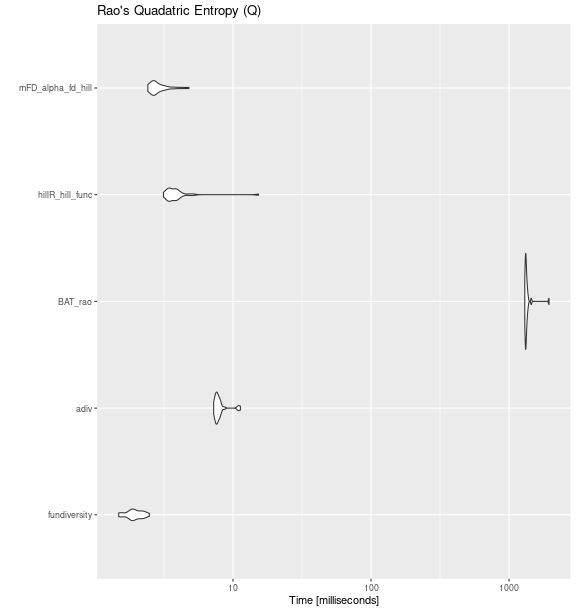

```r
raoq_bench <- fric_bench <- microbenchmark::microbenchmark(
  fundiversity = fd_raoq(traits_birds, site_sp_birds),
  adiv= adiv::QE(
    site_sp_birds, dist_traits_birds
  ),
  BAT_rao           = BAT::rao(
    site_sp_birds, distance = traits_birds
  ),
  hillR_hill_func   = hillR::hill_func(
    site_sp_birds, traits_birds, fdis = FALSE
  ),
  mFD_alpha_fd_hill = mFD::alpha.fd.hill(
    site_sp_birds, dist_traits_birds, q = 2,
    tau = "max"
  ),
  times = 30
)

ggplot2::autoplot(raoq_bench) +
  labs(title = "Rao's Quadatric Entropy (Q)")
```

# Benchmark within `fundiversity`

We now proceed to the performance evaluation of functions within `fundiversity` with datasets of increasing sizes.

## Increasing the number of species

```r
make_more_sp <- function(n) {
  traits <- do.call(rbind, replicate(n, traits_birds, simplify = FALSE))
  row.names(traits) <- paste0("sp", seq_len(nrow(traits)))

  site_sp <- do.call(cbind, replicate(n, site_sp_birds, simplify = FALSE))
  colnames(site_sp) <- paste0("sp", seq_len(ncol(site_sp)))

  list(tr = traits, si = site_sp)
}

null_sp_1000   <- make_more_sp(5)
null_sp_10000  <- make_more_sp(50)
null_sp_100000 <- make_more_sp(500)
```

### Functional Richness

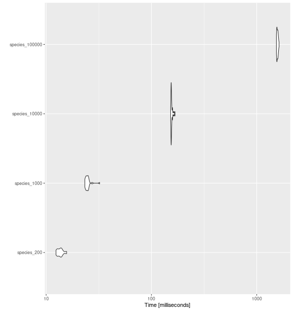

Performance comparison of `fd_fric()` with increasing number of species.

```r
bench_sp_fric <- microbenchmark::microbenchmark(
  species_200    = fd_fric(     traits_birds, site_sp_birds),
  species_1000   = fd_fric(  null_sp_1000$tr, null_sp_1000$si),
  species_10000  = fd_fric( null_sp_10000$tr, null_sp_10000$si),
  species_100000 = fd_fric(null_sp_100000$tr, null_sp_100000$si),
  times = 30
)

ggplot2::autoplot(bench_sp_fric)
```

```r
bench_sp_fric
```

```
#> Unit: milliseconds
#>            expr        min         lq       mean     median         uq        max neval  cld
#>     species_200   12.40461   12.86473   13.63794   13.65822   13.96949   15.64313    30 a
#>    species_1000   23.31024   23.98235   24.77462   24.52898   24.99526   32.20389    30  b
#>   species_10000  152.16972  153.69475  155.65197  154.41463  155.87235  167.39586    30   c
#>  species_100000 1538.24210 1552.02784 1573.05390 1571.92017 1587.70159 1629.76043    30    d
```

### Functional Divergence

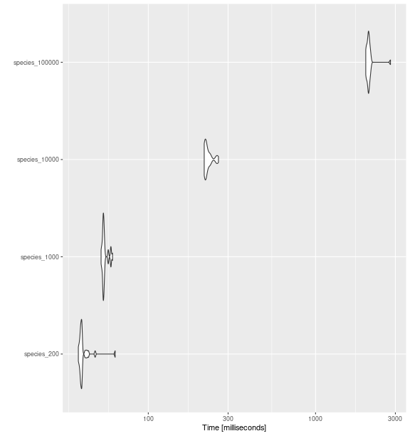

Performance comparison of `fd_fdiv()` with increasing number of species.

```r
bench_sp_fdiv <- microbenchmark::microbenchmark(
  species_200    = fd_fdiv(     traits_birds, site_sp_birds),
  species_1000   = fd_fdiv(  null_sp_1000$tr, null_sp_1000$si),
  species_10000  = fd_fdiv( null_sp_10000$tr, null_sp_10000$si),
  species_100000 = fd_fdiv(null_sp_100000$tr, null_sp_100000$si),
  times = 30
)

ggplot2::autoplot(bench_sp_fdiv)
```

```r
bench_sp_fdiv
```

```
#> Unit: milliseconds
#>            expr        min         lq       mean     median         uq        max neval cld
#>     species_200   38.18281   39.33241   41.03782   39.80735   40.19474   63.38092    30 a
#>    species_1000   52.21140   53.58856   54.88775   54.00482   54.58979   61.12244    30 a
#>   species_10000  215.96505  218.21261  227.32449  221.46767  231.33971  262.64920    30  b
#>  species_100000 1996.22764 2035.16809 2090.07993 2068.75306 2097.02749 2805.37816    30   c
```

### Rao’s Quadratic Entropy

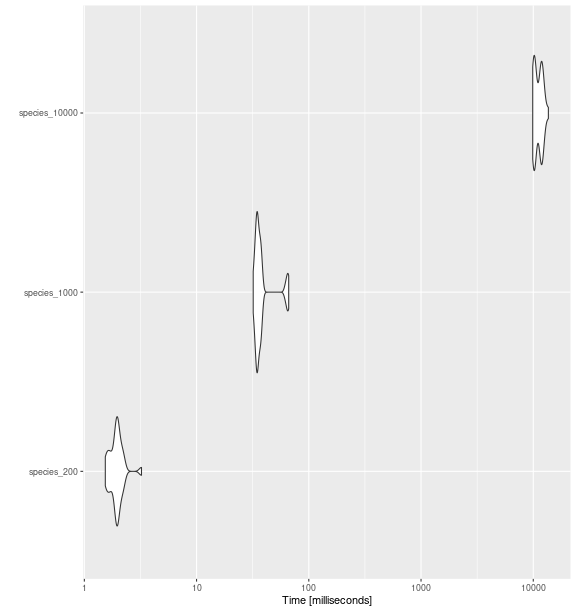

Performance comparison of `fd_raoq()` with increasing number of species.

```r
bench_sp_raoq <- microbenchmark::microbenchmark(
  species_200    = fd_raoq(     traits_birds, site_sp_birds),
  species_1000   = fd_raoq(  null_sp_1000$tr, null_sp_1000$si),
  species_10000  = fd_raoq( null_sp_10000$tr, null_sp_10000$si),
  times = 30
)

ggplot2::autoplot(bench_sp_raoq)
```

```r
bench_sp_raoq
```

```
#> Unit: milliseconds
#>           expr         min           lq         mean       median           uq          max neval cld
#>    species_200    1.537703     1.751935     1.954434     1.950017     2.041037     3.230497    30  a
#>   species_1000   31.957110    34.274255    39.128452    35.156704    37.556228    66.194976    30  a
#>  species_10000 9890.756358 10163.144236 11121.366410 11055.979331 11964.694993 13632.668874    30   b
```

### Functional Evenness

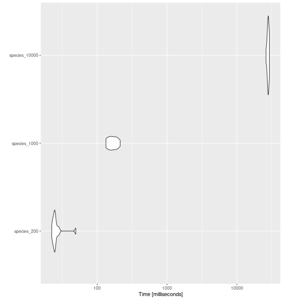

Performance comparison of `fd_feve()` with increasing number of species.

```r
bench_sp_feve <- microbenchmark::microbenchmark(
  species_200    = fd_feve(     traits_birds, site_sp_birds),
  species_1000   = fd_feve(  null_sp_1000$tr, null_sp_1000$si),
  species_10000  = fd_feve( null_sp_10000$tr, null_sp_10000$si),
  times = 15
)

ggplot2::autoplot(bench_sp_feve)
```

```r
bench_sp_feve
```

```
#> Unit: milliseconds
#>           expr         min          lq        mean      median          uq         max neval cld
#>    species_200    22.25434    23.58857    26.28398    24.66652    25.41282    49.21613    15  a
#>   species_1000   133.12192   148.39296   167.29508   163.98844   186.30949   212.94652    15  a
#>  species_10000 26209.90991 27553.75296 28085.39492 28186.57578 28599.03918 29311.05335    15   b
```

### Comparing between indices

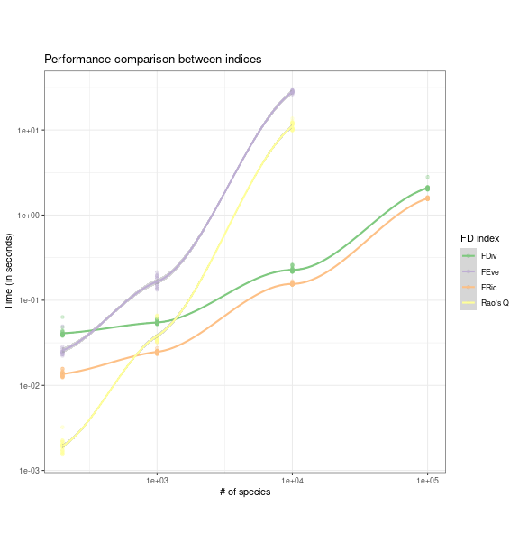

Performance comparison between functions for distinct indices in `fundiversity` with increasing number of species. Smoothed trend lines and standard error envelopes ares shown.

```r
all_bench_sp <- list(fric = bench_sp_fric,
                     fdiv = bench_sp_fdiv,
                     raoq = bench_sp_raoq,
                     feve = bench_sp_feve) %>%
  bind_rows(.id = "fd_index") %>%
  mutate(n_sp = gsub("species_", "", expr) %>%
           as.numeric())

all_bench_sp %>%
  ggplot(aes(n_sp, time * 1e-9, color = fd_index)) +
  geom_point(alpha = 1/3) +
  geom_smooth() +
  scale_x_log10() +
  scale_y_log10() +
  scale_color_brewer(type = "qual",
                     labels = c(fric = "FRic", fdiv = "FDiv", raoq = "Rao's Q",
                                feve = "FEve")) +
  labs(title = "Performance comparison between indices",
       x = "# of species", y = "Time (in seconds)",
       color = "FD index") +
  theme_bw() +
  theme(aspect.ratio = 1)
```

## Increasing the number of sites

```r
make_more_sites <- function(n) {
  site_sp <- do.call(rbind, replicate(n, site_sp_birds, simplify = FALSE))
  rownames(site_sp) <- paste0("s", seq_len(nrow(site_sp)))

  site_sp
}

site_sp_100   <- make_more_sites(12)
site_sp_1000  <- make_more_sites(120)
site_sp_10000 <- make_more_sites(1200)
```

### Functional Richness

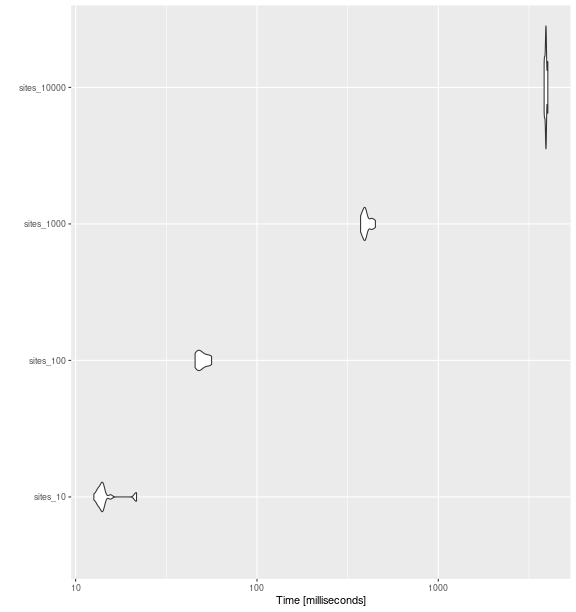

Performance comparison of `fd_fric()` with increasing number of sites.

```r
bench_sites_fric <- microbenchmark::microbenchmark(
  sites_10    = fd_fric(traits_birds, site_sp_birds),
  sites_100   = fd_fric(traits_birds, site_sp_100),
  sites_1000  = fd_fric(traits_birds, site_sp_1000),
  sites_10000 = fd_fric(traits_birds, site_sp_10000),
  times = 15
)

ggplot2::autoplot(bench_sites_fric)
```

```r
bench_sites_fric
```

```
#> Unit: milliseconds
#>         expr        min         lq       mean     median         uq        max neval  cld
#>     sites_10   12.60195   13.45944   14.88054   13.96007   14.29602   21.66510    15 a
#>    sites_100   45.57530   47.25923   49.87524   48.75620   52.29567   56.19952    15  b
#>   sites_1000  372.72833  386.35628  400.43169  395.60903  408.99573  449.87164    15   c
#>  sites_10000 3833.05136 3885.11306 3921.60544 3919.29055 3942.32492 4016.96576    15    d
```

### Functional Divergence

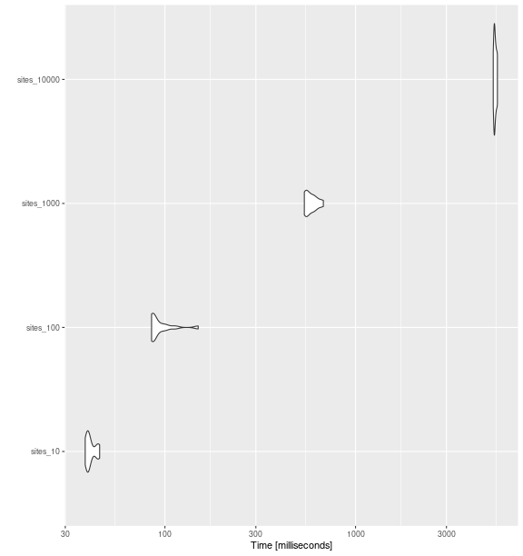

Performance comparison of `fd_fdiv()` with increasing number of sites.

```r
bench_sites_fdiv <- microbenchmark::microbenchmark(
  sites_10    = fd_fdiv(traits_birds, site_sp_birds),
  sites_100   = fd_fdiv(traits_birds, site_sp_100),
  sites_1000  = fd_fdiv(traits_birds, site_sp_1000),
  sites_10000 = fd_fdiv(traits_birds, site_sp_10000),
  times = 15
)

ggplot2::autoplot(bench_sites_fdiv)
```

```r
bench_sites_fdiv
```

```
#> Unit: milliseconds
#>         expr        min         lq       mean     median         uq        max neval  cld
#>     sites_10   38.17040   39.17880   40.79484   39.59029   42.08936   45.43952    15 a
#>    sites_100   85.09805   85.99399   94.77048   86.88365   96.33675  149.45931    15  b
#>   sites_1000  538.76135  545.03628  582.84610  564.85683  605.87486  677.86382    15   c
#>  sites_10000 5278.55172 5336.69296 5405.90861 5378.53730 5458.24597 5552.26594    15    d
```

### Rao’s Quadratic Entropy

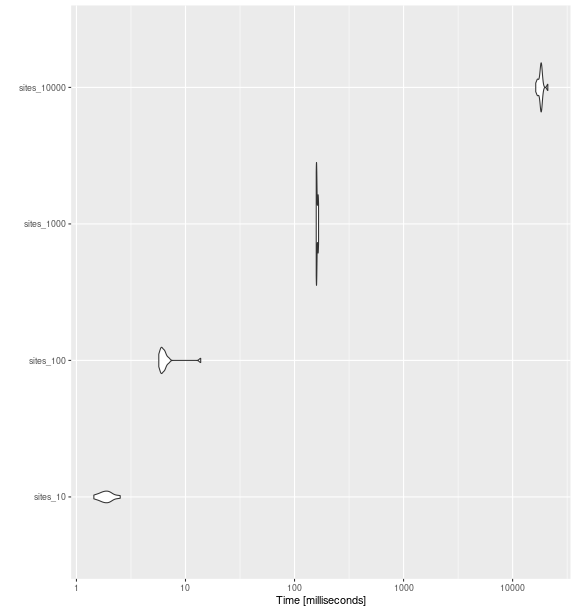

Performance comparison of `fd_raoq()` with increasing number of sites.

```r
bench_sites_raoq = microbenchmark::microbenchmark(
  sites_10    = fd_raoq(traits = NULL, site_sp_birds, dist_traits_birds),
  sites_100   = fd_raoq(traits = NULL, site_sp_100,   dist_traits_birds),
  sites_1000  = fd_raoq(traits = NULL, site_sp_1000,  dist_traits_birds),
  sites_10000 = fd_raoq(traits = NULL, site_sp_10000, dist_traits_birds),
  times = 15
)

ggplot2::autoplot(bench_sites_raoq)
```

```r
bench_sites_raoq
```

```
#> Unit: milliseconds
#>         expr          min           lq         mean       median           uq          max neval cld
#>     sites_10     1.443757     1.717630     1.887153     1.861230     2.037991     2.518933    15  a
#>    sites_100     5.689849     6.004428     6.718675     6.178415     6.460348    13.786219    15  a
#>   sites_1000   158.130064   158.814848   160.907719   159.296631   163.977418   166.066294    15  a
#>  sites_10000 16296.391504 17530.369693 18080.130808 18193.538354 18411.571843 21033.249202    15   b
```

### Functional Evenness

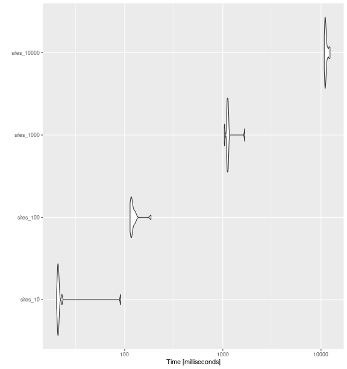

Performance comparison of `fd_feve()` with increasing number of sites

```r
bench_sites_feve <- microbenchmark::microbenchmark(
  sites_10    = fd_feve(traits = NULL, site_sp_birds, dist_traits_birds),
  sites_100   = fd_feve(traits = NULL, site_sp_100,   dist_traits_birds),
  sites_1000  = fd_feve(traits = NULL, site_sp_1000,  dist_traits_birds),
  sites_10000 = fd_feve(traits = NULL, site_sp_10000, dist_traits_birds),
  times = 15
)

ggplot2::autoplot(bench_sites_feve)
```

```r
bench_sites_feve
```

```
#> Unit: milliseconds
#>         expr         min          lq        mean      median          uq         max neval cld
#>     sites_10    20.26885    20.79379    25.80265    21.06491    21.39182    90.92815    15 a
#>    sites_100   113.64419   115.81009   123.60943   118.04145   123.54457   185.57582    15 a
#>   sites_1000  1034.37573  1107.36408  1146.78358  1119.68000  1134.07348  1668.68480    15  b
#>  sites_10000 10779.65515 10969.94333 11249.27062 11090.00824 11317.37080 12341.22800    15   c
```

### Comparing between indices

[figure not shown]

```r
all_bench_sites <- list(fric = bench_sites_fric,
                        fdiv = bench_sites_fdiv,
                        raoq = bench_sites_raoq,
                        feve = bench_sites_feve) %>%
  bind_rows(.id = "fd_index") %>%
  mutate(n_sites = gsub("sites", "", expr) %>%
           as.numeric())

all_bench_sites %>%
  ggplot(aes(n_sites, time * 1e-9, color = fd_index)) +
  geom_point(alpha = 1/3) +
  geom_smooth() +
  scale_x_log10() +
  scale_y_log10() +
  scale_color_brewer(type = "qual",
                     labels = c(fric = "FRic", fdiv = "FDiv", raoq = "Rao's Q",
                                feve = "FEve")) +
  labs(title = "Performance comparison between indices",
       x = "# of sites", y = "Time (in seconds)",
       color = "FD index") +
  theme_bw() +
  theme(aspect.ratio = 1)
```

# References

Baselga, Andrés, and C. David L. Orme. 2012. “Betapart: An R Package for the Study of Beta Diversity.” *Methods in Ecology and Evolution* 3 (5): 808–12. https://doi.org/10.1111/j.2041-210X.2012.00224.x.

Cardoso, Pedro, François Rigal, and José C. Carvalho. 2015. “BAT Biodiversity Assessment Tools, an R Package for the Measurement and Estimation of Alpha and Beta Taxon, Phylogenetic and Functional Diversity.” *Methods in Ecology and Evolution* 6 (2): 232–36. https://doi.org/10.1111/2041-210X.12310.

Laliberté, Etienne, and Pierre Legendre. 2010. “A Distance-Based Framework for Measuring Functional Diversity from Multiple Traits.” *Ecology* 91 (1): 299–305. https://doi.org/10.1890/08-2244.1.

Laliberté, Etienne, Pierre Legendre, and Bill Shipley. 2014. *FD: Measuring Functional Diversity from Multiple Traits, and Other Tools for Functional Ecology*.

Li, Daijiang. 2018. “hillR: Taxonomic, Functional, and Phylogenetic Diversity and Similarity Through Hill Numbers.” *Journal of Open Source Software* 3 (31): 1041. https://doi.org/10.21105/joss.01041.

Magneville, Camille, Nicolas Loiseau, Camille Albouy, Nicolas Casajus, Thomas Claverie, Arthur Escalas, Fabien Leprieur, Eva Maire, David Mouillot, and Sébastien Villéger. 2022. “mFD: An R Package to Compute and Illustrate the Multiple Facets of Functional Diversity.” *Ecography* 2022 (1). https://doi.org/10.1111/ecog.05904.

Pavoine, Sandrine. 2020. “adiv: An r Package to Analyse Biodiversity in Ecology.” *Methods in Ecology and Evolution* 11 (9): 1106–12. https://doi.org/10.1111/2041-210X.13430.

Rao, C. Radhakrishna. 1982. “Diversity and Dissimilarity Coefficients: A Unified Approach.” *Theoretical Population Biology* 21 (1): 24–43. https://doi.org/10.1016/0040-5809(82)90004-1.

Ricotta, Carlo, and Laszlo Szeidl. 2009. “Diversity Partitioning of Rao’s Quadratic Entropy.” *Theoretical Population Biology* 76 (4): 299–302. https://doi.org/10.1016/j.tpb.2009.10.001.

Villéger, Sébastien, Gaël Grenouillet, and Sébastien Brosse. 2013. “Decomposing Functional $\beta$-Diversity Reveals That Low Functional $\beta$-Diversity Is Driven by Low Functional Turnover in European Fish Assemblages.” *Global Ecology and Biogeography* 22 (6): 671–81. https://doi.org/10.1111/geb.12021.

Villéger, Sébastien, Norman W. H. Mason, and David Mouillot. 2008. “New Multidimensional Functional Diversity Indices for a Multifaceted Framework in Functional Ecology.” *Ecology* 89 (8): 2290–2301. https://doi.org/10.1890/07-1206.1.